# R Notebook

##Homework

1. Choose an appropriate machine learning dataset and use SVM with two different kernels. Campare the results.
2. Attempt using SVM after using a previously covered feature selection method. Do the results improve? Explain.

```r
library(tidyverse)
library(mlbench)
library(caret)
library(pROC)
```

#Load in Dataset and transform the data

```r
data("PimaIndiansDiabetes")
head(PimaIndiansDiabetes)
```

|  | pregnant | glucose | pressure | triceps | insulin | mass | pedigree | age | diabetes |
| --- | --- | --- | --- | --- | --- | --- | --- | --- | --- |
| 1 | 6 | 148 | 72 | 35 | 0 | 33.6 | 0.627 | 50 | pos |
| 2 | 1 | 85 | 66 | 29 | 0 | 26.6 | 0.351 | 31 | neg |
| 3 | 8 | 183 | 64 | 0 | 0 | 23.3 | 0.672 | 32 | pos |
| 4 | 1 | 89 | 66 | 23 | 94 | 28.1 | 0.167 | 21 | neg |
| 5 | 0 | 137 | 40 | 35 | 168 | 43.1 | 2.288 | 33 | pos |
| 6 | 5 | 116 | 74 | 0 | 0 | 25.6 | 0.201 | 30 | neg |

```r
dim(PimaIndiansDiabetes)
```

```
## [1] 768   9
```

```r
summary(PimaIndiansDiabetes$diabetes)
```

```
## neg pos
## 500 268
```

```r
PimaIndians_num = transform(PimaIndiansDiabetes, pregnant = as.numeric(pregnant),
                         glucose = as.numeric(glucose),
                         pressure = as.numeric(pressure),
                         triceps = as.numeric(triceps),
                         insulin = as.numeric(insulin),
                         mass = as.numeric(mass),
                         pedigree = as.numeric(pedigree),
                         age = as.numeric(age))

PimaIndians_num[is.na(PimaIndians_num)] = 0
```

#Create Test and training sets

```r
train_size = floor(0.75 * nrow(PimaIndians_num))
train_pos <- sample(seq_len(nrow(PimaIndians_num)), size = train_size)

train_classification <- PimaIndians_num[train_pos, ]
test_classification <- PimaIndians_num[-train_pos, ]
```

#SVM with Linear Kernel

```r
set.seed(112)
control = trainControl(method = "repeatedcv", repeats = 5, classProbs = T, savePredictions = T, allowParallel = T)

svm = train(diabetes ~ pregnant + glucose + pressure + triceps + insulin + mass + pedigree + age ,  data = train_classification, method = "svmLinear", tuneLength = 10, trControl = control)

svm
```

```
## Support Vector Machines with Linear Kernel
##
## 576 samples
##   8 predictor
##   2 classes: 'neg', 'pos'
##
## No pre-processing
## Resampling: Cross-Validated (10 fold, repeated 5 times)
## Summary of sample sizes: 518, 519, 517, 519, 518, 518, ...
## Resampling results:
##
##   Accuracy   Kappa
##   0.7830285  0.4976051
##
## Tuning parameter 'C' was held constant at a value of 1
```

#ROC

```r
roc(predictor = svm$pred$pos, response = svm$pred$obs)$auc
```

```
## Area under the curve: 0.8324
```

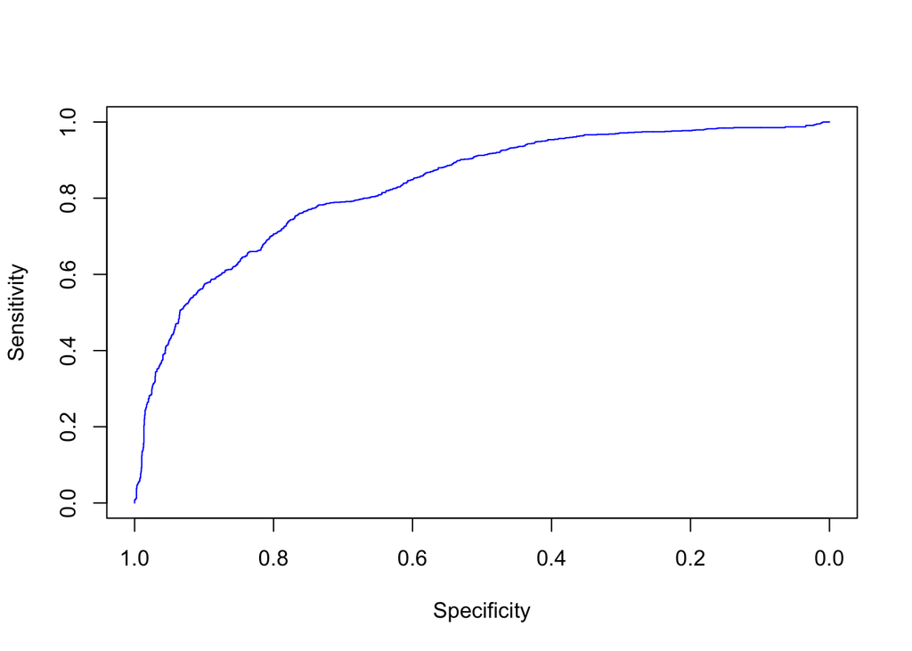

```r
plot(x = roc(predictor = svm$pred$pos, response = svm$pred$obs)$specificities, y = roc(predictor = svm$pred$pos, response = svm$pred$obs)$sensitivities, col= "blue", xlim = c(1, 0), type ="l", ylab = "Sensitivity", xlab = "Specificity")
```

#Test Set Confusion Matrix

```r
svm_test = predict(svm, newdata = test_classification)
confusionMatrix(svm_test, reference = test_classification$diabetes)
```

```
## Confusion Matrix and Statistics
##
##           Reference
## Prediction neg pos
##        neg 106  30
##        pos  21  35
##
##                Accuracy : 0.7344
##                  95% CI : (0.666, 0.7954)
##     No Information Rate : 0.6615
##     P-Value [Acc > NIR] : 0.0183
##
##                   Kappa : 0.3862
##
##  Mcnemar's Test P-Value : 0.2626
##
##             Sensitivity : 0.8346
##             Specificity : 0.5385
##          Pos Pred Value : 0.7794
##          Neg Pred Value : 0.6250
##              Prevalence : 0.6615
##          Detection Rate : 0.5521
##    Detection Prevalence : 0.7083
##       Balanced Accuracy : 0.6866
##
##        'Positive' Class : neg
##
```

#SVM with radial kernel

```r
set.seed(112)
control = trainControl(method = "repeatedcv", repeats = 5, classProbs = T, savePredictions = T, allowParallel = T)

svm = train(diabetes ~ pregnant + glucose + pressure + triceps + insulin + mass + pedigree + age ,  data = train_classification, method = "svmRadial", tuneLength = 10, trControl = control)

svm
```

```
## Support Vector Machines with Radial Basis Function Kernel
##
## 576 samples
##   8 predictor
##   2 classes: 'neg', 'pos'
##
## No pre-processing
## Resampling: Cross-Validated (10 fold, repeated 5 times)
## Summary of sample sizes: 518, 519, 517, 519, 518, 518, ...
## Resampling results across tuning parameters:
##
##   C       Accuracy   Kappa
##     0.25  0.7765001  0.4909508
##     0.50  0.7788843  0.4935686
##     1.00  0.7709230  0.4718941
##     2.00  0.7604451  0.4453853
##     4.00  0.7604568  0.4460296
##     8.00  0.7420293  0.3955677
##    16.00  0.7218704  0.3399739
##    32.00  0.7089302  0.2987354
##    64.00  0.6967465  0.2573367
##   128.00  0.6901579  0.2367322
##
## Tuning parameter 'sigma' was held constant at a value of 0.1487211
## Accuracy was used to select the optimal model using the largest value.
## The final values used for the model were sigma = 0.1487211 and C = 0.5.
```

#ROC

```r
roc(predictor = svm$pred$pos, response = svm$pred$obs)$auc
```

```
## Area under the curve: 0.785
```

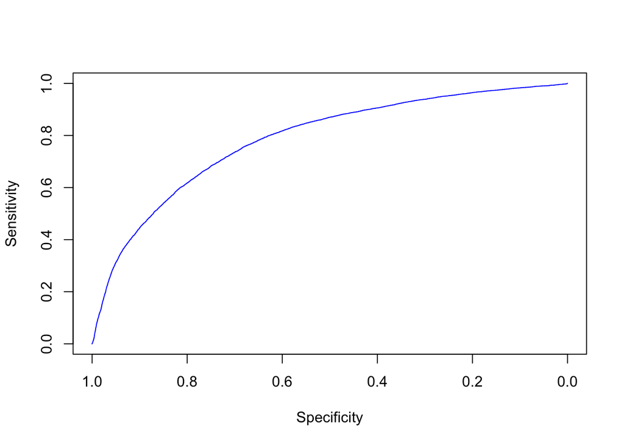

```r
plot(x = roc(predictor = svm$pred$pos, response = svm$pred$obs)$specificities, y = roc(predictor = svm$pred$pos, response = svm$pred$obs)$sensitivities, col= "blue", xlim = c(1, 0), type ="l", ylab = "Sensitivity", xlab = "Specificity")
```

#Confusion Matrix

```r
svm_test = predict(svm, newdata = test_classification)
confusionMatrix(svm_test, reference = test_classification$diabetes)
```

```
## Confusion Matrix and Statistics
##
##           Reference
## Prediction neg pos
##        neg 105  29
##        pos  22  36
##
##                Accuracy : 0.7344
##                  95% CI : (0.666, 0.7954)
##     No Information Rate : 0.6615
##     P-Value [Acc > NIR] : 0.0183
##
##                   Kappa : 0.3909
##
##  Mcnemar's Test P-Value : 0.4008
##
##             Sensitivity : 0.8268
##             Specificity : 0.5538
##          Pos Pred Value : 0.7836
##          Neg Pred Value : 0.6207
##              Prevalence : 0.6615
##          Detection Rate : 0.5469
##    Detection Prevalence : 0.6979
##       Balanced Accuracy : 0.6903
##
##        'Positive' Class : neg
##
```

#Feature Selection

For this portion, I will perform feature selection using the RFE Algorithm

```r
#define the control
control = rfeControl(functions = caretFuncs, number = 2)

# run the RFE algorithm
results = rfe(PimaIndians_num[,1:8], PimaIndians_num[,9], sizes = c(2,5,8), rfeControl = control, method = "svmRadial")

results
```

```
##
## Recursive feature selection
##
## Outer resampling method: Bootstrapped (2 reps)
##
## Resampling performance over subset size:
##
##  Variables Accuracy  Kappa AccuracySD   KappaSD Selected
##          2   0.7558 0.4314   0.003137 1.035e-05
##          5   0.7647 0.4526   0.025802 6.209e-02
##          8   0.7700 0.4650   0.033351 9.800e-02        *
##
## The top 5 variables (out of 8):
##    glucose, age, mass, pregnant, pedigree
```

```r
results$variables
```

| neg | pos | Overall | var | Variables | Resample |
| --- | --- | --- | --- | --- | --- |
| 0.7893923 | 0.7893923 | 0.7893923 | glucose | 8 | Resample1 |
| 0.6916101 | 0.6916101 | 0.6916101 | mass | 8 | Resample1 |
| 0.6796875 | 0.6796875 | 0.6796875 | age | 8 | Resample1 |
| 0.6300477 | 0.6300477 | 0.6300477 | pregnant | 8 | Resample1 |
| 0.5837435 | 0.5837435 | 0.5837435 | pedigree | 8 | Resample1 |
| 0.5640158 | 0.5640158 | 0.5640158 | pressure | 8 | Resample1 |
| 0.5405079 | 0.5405079 | 0.5405079 | triceps | 8 | Resample1 |
| 0.5091356 | 0.5091356 | 0.5091356 | insulin | 8 | Resample1 |
| 0.7893923 | 0.7893923 | 0.7893923 | glucose | 5 | Resample1 |
| 0.6916101 | 0.6916101 | 0.6916101 | mass | 5 | Resample1 |

[output cut: 20 more lines]

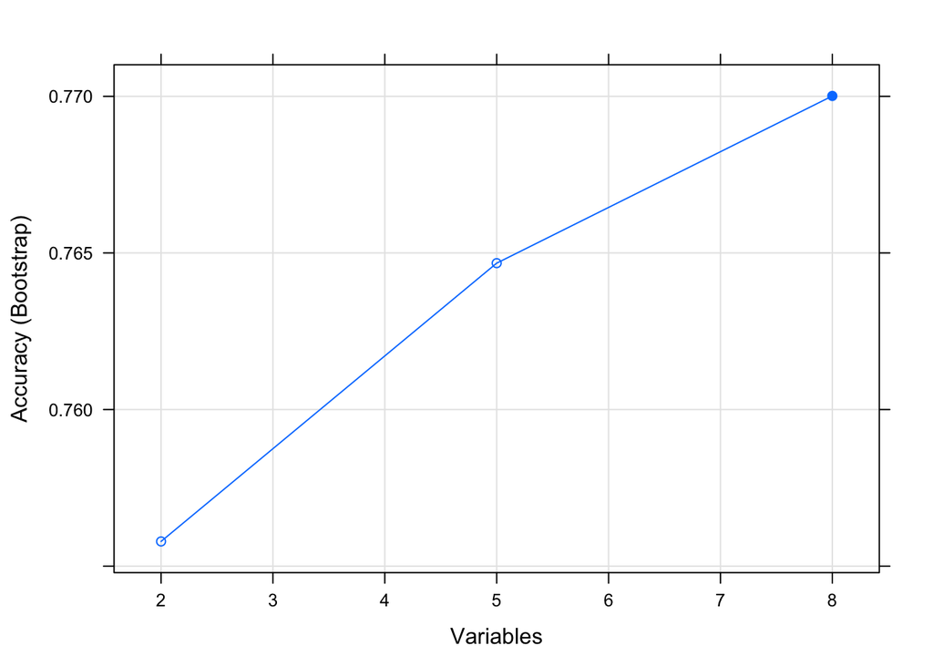

```r
plot(results, type=c("g", "o"))
```

```r
predictors(results)
```

```
## [1] "glucose"  "age"      "mass"     "pregnant" "pedigree" "pressure" "triceps"
## [8] "insulin"
```

This feature selection method has determined that the top five variables are glucose, mass, age, pregnant, and pedigree. Therefore, I will use solely these five variables for building the model. However, feature selection also shows that the best models for this dataset are built using all eight variables. Therefore, I will attempt SVM using the top five variables, yet expect these models to perform slightly worse than the models I have previously constructed

#SVM with Linear Kernel Again

```r
set.seed(112)
control = trainControl(method = "repeatedcv", repeats = 5, classProbs = T, savePredictions = T, allowParallel = T)

svm = train(diabetes ~ glucose + mass + age + pregnant + pedigree,  data = train_classification, method = "svmLinear", tuneLength = 10, trControl = control)

svm
```

```
## Support Vector Machines with Linear Kernel
##
## 576 samples
##   5 predictor
##   2 classes: 'neg', 'pos'
##
## No pre-processing
## Resampling: Cross-Validated (10 fold, repeated 5 times)
## Summary of sample sizes: 518, 519, 517, 519, 518, 518, ...
## Resampling results:
##
##   Accuracy   Kappa
##   0.7729686  0.4741334
##
## Tuning parameter 'C' was held constant at a value of 1
```

```r
roc(predictor = svm$pred$pos, response = svm$pred$obs)$auc
```

```
## Area under the curve: 0.8306
```

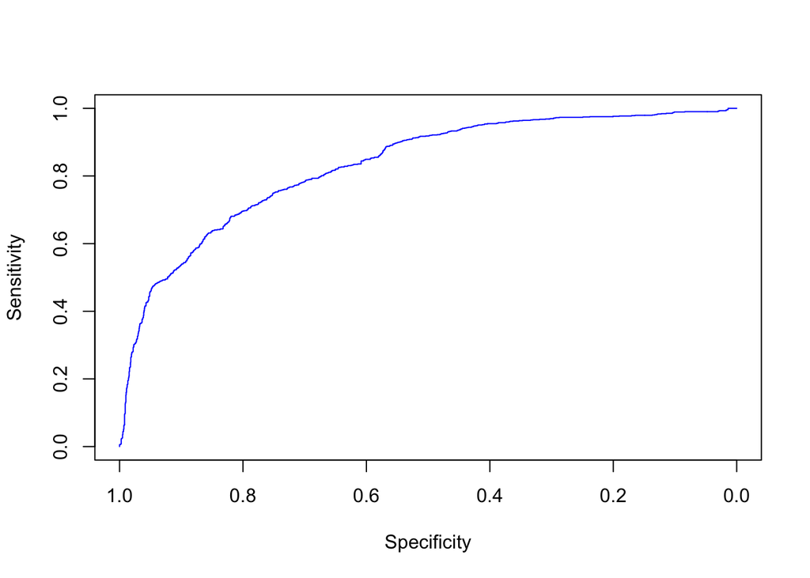

```r
plot(x = roc(predictor = svm$pred$pos, response = svm$pred$obs)$specificities, y = roc(predictor = svm$pred$pos, response = svm$pred$obs)$sensitivities, col= "blue", xlim = c(1, 0), type ="l", ylab = "Sensitivity", xlab = "Specificity")
```

#Confusion matrix

```r
svm_test = predict(svm, newdata = test_classification)
confusionMatrix(svm_test, reference = test_classification$diabetes)
```

```
## Confusion Matrix and Statistics
##
##           Reference
## Prediction neg pos
##        neg 108  29
##        pos  19  36
##
##                Accuracy : 0.75
##                  95% CI : (0.6826, 0.8096)
##     No Information Rate : 0.6615
##     P-Value [Acc > NIR] : 0.00509
##
##                   Kappa : 0.42
##
##  Mcnemar's Test P-Value : 0.19393
##
##             Sensitivity : 0.8504
##             Specificity : 0.5538
##          Pos Pred Value : 0.7883
##          Neg Pred Value : 0.6545
##              Prevalence : 0.6615
##          Detection Rate : 0.5625
##    Detection Prevalence : 0.7135
##       Balanced Accuracy : 0.7021
##
##        'Positive' Class : neg
##
```

The accuracy improved slightly for this model

#SVM with Radial Kernel Again

```r
set.seed(112)
control = trainControl(method = "repeatedcv", repeats = 5, classProbs = T, savePredictions = T, allowParallel = T)

svm = train(diabetes ~ glucose + mass + age + pregnant + pedigree,  data = train_classification, method = "svmRadial", tuneLength = 10, trControl = control)

svm
```

```
## Support Vector Machines with Radial Basis Function Kernel
##
## 576 samples
##   5 predictor
##   2 classes: 'neg', 'pos'
##
## No pre-processing
## Resampling: Cross-Validated (10 fold, repeated 5 times)
## Summary of sample sizes: 518, 519, 517, 519, 518, 518, ...
## Resampling results across tuning parameters:
##
##   C       Accuracy   Kappa
##     0.25  0.7663015  0.4600922
##     0.50  0.7625026  0.4479368
##     1.00  0.7541896  0.4279045
##     2.00  0.7499615  0.4161494
##     4.00  0.7388176  0.3852956
##     8.00  0.7311525  0.3612714
##    16.00  0.7248968  0.3451512
##    32.00  0.7245278  0.3368348
##    64.00  0.7137595  0.3032221
##   128.00  0.7102926  0.2875638
##
## Tuning parameter 'sigma' was held constant at a value of 0.2809674
## Accuracy was used to select the optimal model using the largest value.
## The final values used for the model were sigma = 0.2809674 and C = 0.25.
```

#ROC

```r
roc(predictor = svm$pred$pos, response = svm$pred$obs)$auc
```

```
## Area under the curve: 0.7799
```

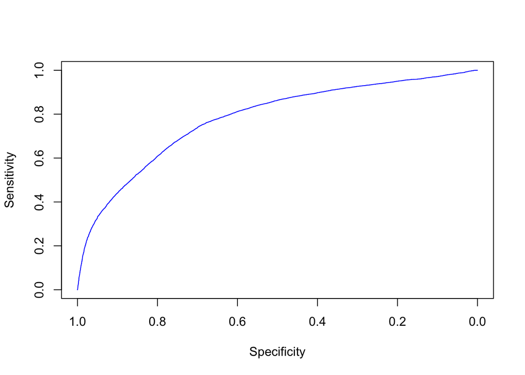

```r
plot(x = roc(predictor = svm$pred$pos, response = svm$pred$obs)$specificities, y = roc(predictor = svm$pred$pos, response = svm$pred$obs)$sensitivities, col= "blue", xlim = c(1, 0), type ="l", ylab = "Sensitivity", xlab = "Specificity")
```

#Confusion Matrix

```r
svm_test = predict(svm, newdata = test_classification)
confusionMatrix(svm_test, reference = test_classification$diabetes)
```

```
## Confusion Matrix and Statistics
##
##           Reference
## Prediction neg pos
##        neg 107  29
##        pos  20  36
##
##                Accuracy : 0.7448
##                  95% CI : (0.677, 0.8048)
##     No Information Rate : 0.6615
##     P-Value [Acc > NIR] : 0.007994
##
##                   Kappa : 0.4102
##
##  Mcnemar's Test P-Value : 0.253098
##
##             Sensitivity : 0.8425
##             Specificity : 0.5538
##          Pos Pred Value : 0.7868
##          Neg Pred Value : 0.6429
##              Prevalence : 0.6615
##          Detection Rate : 0.5573
##    Detection Prevalence : 0.7083
##       Balanced Accuracy : 0.6982
##
##        'Positive' Class : neg
##
```

Just as I expected, the AUCs for both linear and radial kernels performed slightly worse with five variables than with eight variables, yet were still relatively similar to the models previously constructed